# Red Wine Exploratory Data Analysis by R

Anouar Zbaida

nov 28, 2017

# Introduction

In this project we will explores the univariate, bivariate, & multivariate relationships between variables using exploratory data analysis (EDA) techniques in R. To do so we are going to use a [tidy data](http://vita.had.co.nz/papers/tidy-data.pdf) that is created - using red wine samples - on 2009 by P.cortez and al, the dataset is related to variants of the Portuguese [“Vinho Verde”](https://en.wikipedia.org/wiki/Vinho_Verde) wine.

### About the dataset

This dataset is public available for research. The details are described in [Cortez et al., 2009].

P. Cortez, A. Cerdeira, F. Almeida, T. Matos and J. Reis. Modeling wine preferences by data mining from physicochemical properties. In Decision Support Systems, Elsevier, 47(4):547-553. ISSN: 0167-9236.

Available at:

- [Elsevier](http://dx.doi.org/10.1016/j.dss.2009.05.016)
- [Pre-press (pdf)](http://www3.dsi.uminho.pt/pcortez/winequality09.pdf)
- bib

### Variable description

- **Fixed acidity**: most acids involved with wine or fixed or nonvolatile (do not evaporate readily)
- **Volatile acidity**: the amount of acetic acid in wine, which at too high of levels can lead to an unpleasant, vinegar taste
- **Citric acid**: found in small quantities, citric acid can add ‘freshness’ and flavor to wines
- **Residual sugar**: the amount of sugar remaining after fermentation stops, it’s rare to find wines with less than 1 gram/liter and wines with greater than 45 grams/liter are considered sweet
- **Chlorides**: the amount of salt in the wine
- **Free sulfur dioxide**: the free form of SO2 exists in equilibrium between molecular SO2 (as a dissolved gas) and bisulfite ion; it prevents microbial growth and the oxidation of wine
- **Total sulfur dioxide**: amount of free and bound forms of S02; in low concentrations, SO2 is mostly undetectable in wine, but at free SO2 concentrations over 50 ppm, SO2 becomes evident in the nose and taste of wine
- **Density**: the density of water is close to that of water depending on the percent alcohol and sugar content
- **pH**: describes how acidic or basic a wine is on a scale from 0 (very acidic) to 14 (very basic); most wines are between 3-4 on the pH scale
- **Sulphates**: a wine additive which can contribute to sulfur dioxide gas (S02) levels, wich acts as an antimicrobial and antioxidant
- **Alcohol**: the percent alcohol content of the wine
- **Quality**: output variable (based on sensory data, score between 0 and 10)

### Variable information

Input variables (based on physicochemical tests):

- fixed acidity (tartaric acid - g / dm^3)
- volatile acidity (acetic acid - g / dm^3)
- citric acid (g / dm^3)
- residual sugar (g / dm^3)
- chlorides (sodium chloride - g / dm^3
- free sulfur dioxide (mg / dm^3)
- total sulfur dioxide (mg / dm^3)
- density (g / cm^3)
- pH
- sulphates (potassium sulphate - g / dm3)
- alcohol (% by volume)

Output variable (based on sensory data):

- quality (score between 0 and 10)

# Exploring Data

### Loading up libraries for project

- ggplot2 : Needed for graphs
- dplyr: Needed for data manipulation functions
- gridExtra: Allows multiple graphs in a single grid
- reshape: used for melt and cast functions (data aggregation)
- RColorBrewer: Creates nice looking color palettes especially for thematic maps
- lattice: an implementation of Trellis graphics for R
- scales: Generic plot scaling methods
- memisc: This package collects an assortment of tools that are intended to make work with R easier
- reshape: melt and cast functions (data aggregation)
- sandwich: Constructing sandwich covariance matrix estimators by multiplying bread and meat matrices
- graphics: functions for ‘base’ graphics

### Summary Statistics

Let’s run some basic functions to examine the structure and schema of the data set.

```
## 'data.frame':    1599 obs. of  13 variables:
##  $ X                   : int  1 2 3 4 5 6 7 8 9 10 ...
##  $ fixed.acidity       : num  7.4 7.8 7.8 11.2 7.4 7.4 7.9 7.3 7.8 7.5 ...
##  $ volatile.acidity    : num  0.7 0.88 0.76 0.28 0.7 0.66 0.6 0.65 0.58 0.5 ...
##  $ citric.acid         : num  0 0 0.04 0.56 0 0 0.06 0 0.02 0.36 ...
##  $ residual.sugar      : num  1.9 2.6 2.3 1.9 1.9 1.8 1.6 1.2 2 6.1 ...
##  $ chlorides           : num  0.076 0.098 0.092 0.075 0.076 0.075 0.069 0.065 0.073 0.071 ...
##  $ free.sulfur.dioxide : num  11 25 15 17 11 13 15 15 9 17 ...
##  $ total.sulfur.dioxide: num  34 67 54 60 34 40 59 21 18 102 ...
##  $ density             : num  0.998 0.997 0.997 0.998 0.998 ...
##  $ pH                  : num  3.51 3.2 3.26 3.16 3.51 3.51 3.3 3.39 3.36 3.35 ...
##  $ sulphates           : num  0.56 0.68 0.65 0.58 0.56 0.56 0.46 0.47 0.57 0.8 ...
##  $ alcohol             : num  9.4 9.8 9.8 9.8 9.4 9.4 9.4 10 9.5 10.5 ...
##  $ quality             : int  5 5 5 6 5 5 5 7 7 5 ...
```

There are 1599 observations and 13 variables in this data set.

```
##        X          fixed.acidity   volatile.acidity  citric.acid
##  Min.   :   1.0   Min.   : 4.60   Min.   :0.1200   Min.   :0.000
##  1st Qu.: 400.5   1st Qu.: 7.10   1st Qu.:0.3900   1st Qu.:0.090
##  Median : 800.0   Median : 7.90   Median :0.5200   Median :0.260
##  Mean   : 800.0   Mean   : 8.32   Mean   :0.5278   Mean   :0.271
##  3rd Qu.:1199.5   3rd Qu.: 9.20   3rd Qu.:0.6400   3rd Qu.:0.420
##  Max.   :1599.0   Max.   :15.90   Max.   :1.5800   Max.   :1.000
##  residual.sugar     chlorides       free.sulfur.dioxide
##  Min.   : 0.900   Min.   :0.01200   Min.   : 1.00
##  1st Qu.: 1.900   1st Qu.:0.07000   1st Qu.: 7.00
##  Median : 2.200   Median :0.07900   Median :14.00
##  Mean   : 2.539   Mean   :0.08747   Mean   :15.87
##  3rd Qu.: 2.600   3rd Qu.:0.09000   3rd Qu.:21.00
##  Max.   :15.500   Max.   :0.61100   Max.   :72.00
##  total.sulfur.dioxide    density             pH          sulphates
##  Min.   :  6.00       Min.   :0.9901   Min.   :2.740   Min.   :0.3300
##  1st Qu.: 22.00       1st Qu.:0.9956   1st Qu.:3.210   1st Qu.:0.5500
##  Median : 38.00       Median :0.9968   Median :3.310   Median :0.6200
##  Mean   : 46.47       Mean   :0.9967   Mean   :3.311   Mean   :0.6581
##  3rd Qu.: 62.00       3rd Qu.:0.9978   3rd Qu.:3.400   3rd Qu.:0.7300
##  Max.   :289.00       Max.   :1.0037   Max.   :4.010   Max.   :2.0000
##     alcohol         quality
##  Min.   : 8.40   Min.   :3.000
##  1st Qu.: 9.50   1st Qu.:5.000
##  Median :10.20   Median :6.000
##  Mean   :10.42   Mean   :5.636
##  3rd Qu.:11.10   3rd Qu.:6.000
##  Max.   :14.90   Max.   :8.000
```

- No observations have a quality greater than 8
- Quality is an ordinal categorical variable. Since we’re primarily interested in quality a new variable will be created from quality for subsquent analysis
- All other variables seem to be continuous quantities (except the sulfur.dioxide suffixes)
- From the variable descriptions, it appears that fixed.acidity ~ volatile.acidity and free.sulfur.dioxide ~ total.sulfur.dioxide may possible by dependent, subsets of each other

# Univariate Plots Section

In this section, we should perform some preliminary exploration of our dataset. Let’s run some summaries of the data and create univariate plots to understand the structure of the individual variables in our dataset.

### Quality

The goal of this studies is trying to understand which variables are responsible for the quality of the wine. So let’s start with quality variable.

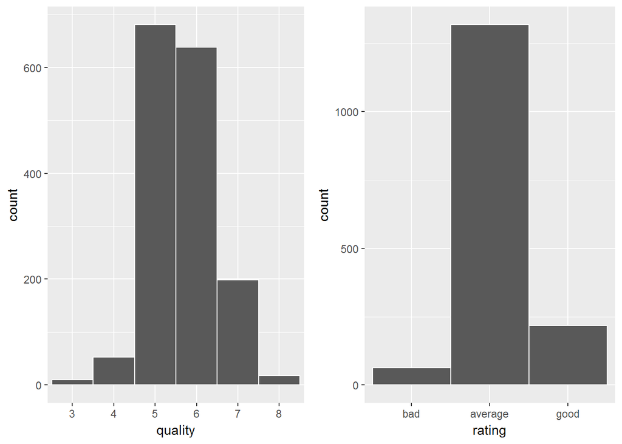

```
##   3   4   5   6   7   8
##  10  53 681 638 199  18
```

- A large majority of the wines examined received ratings of 5 or 6, and very few received 3, 4, or 8
- More than 50 % of wines rated average

### Fixed Acidity

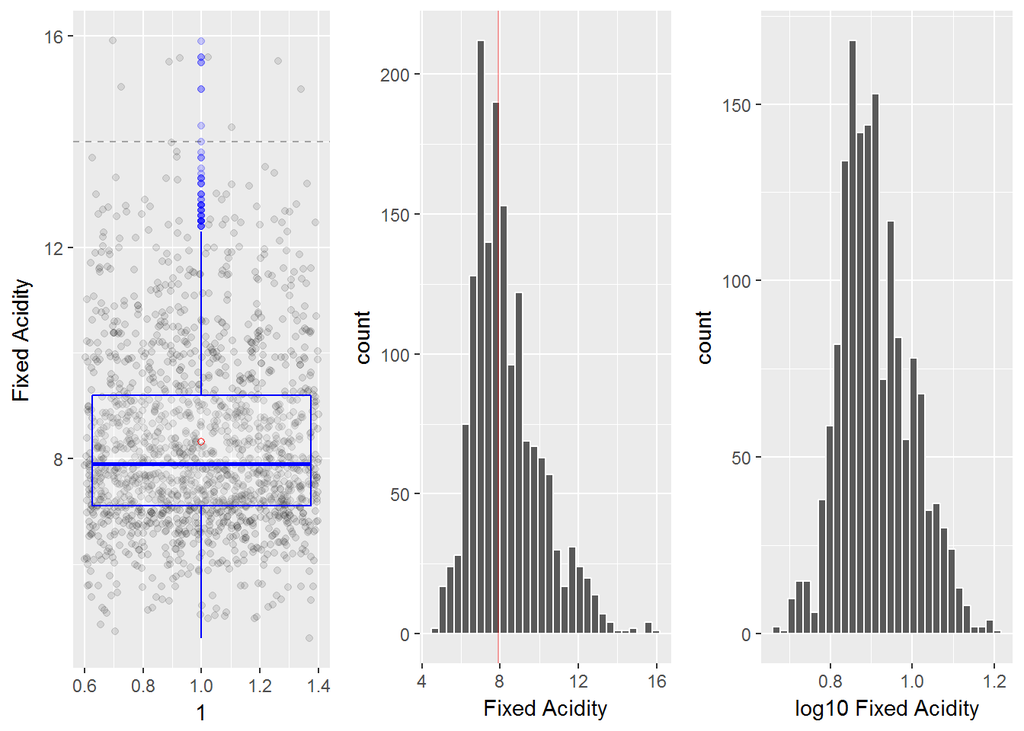

```
##    Min. 1st Qu.  Median    Mean 3rd Qu.    Max.
##    4.60    7.10    7.90    8.32    9.20   15.90
```

- Fixed acidity has a long-tail distribution.
- The log10 plot normalize the distribution.
- A peak around 7, a median of 7.90 and vary around 4 and 15.90

### Volatile Acidity

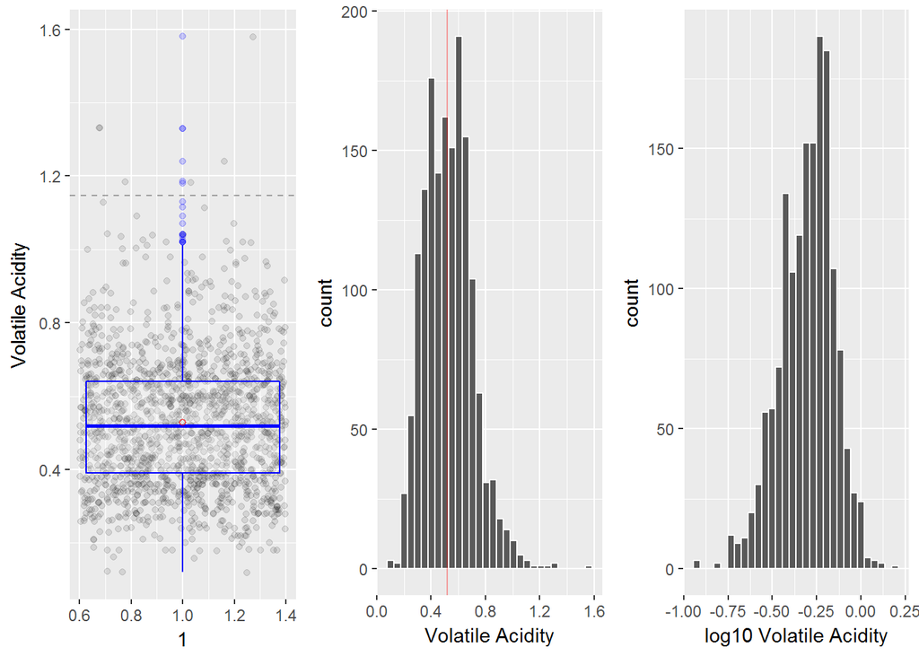

```
##    Min. 1st Qu.  Median    Mean 3rd Qu.    Max.
##  0.1200  0.3900  0.5200  0.5278  0.6400  1.5800
```

### citric Acid

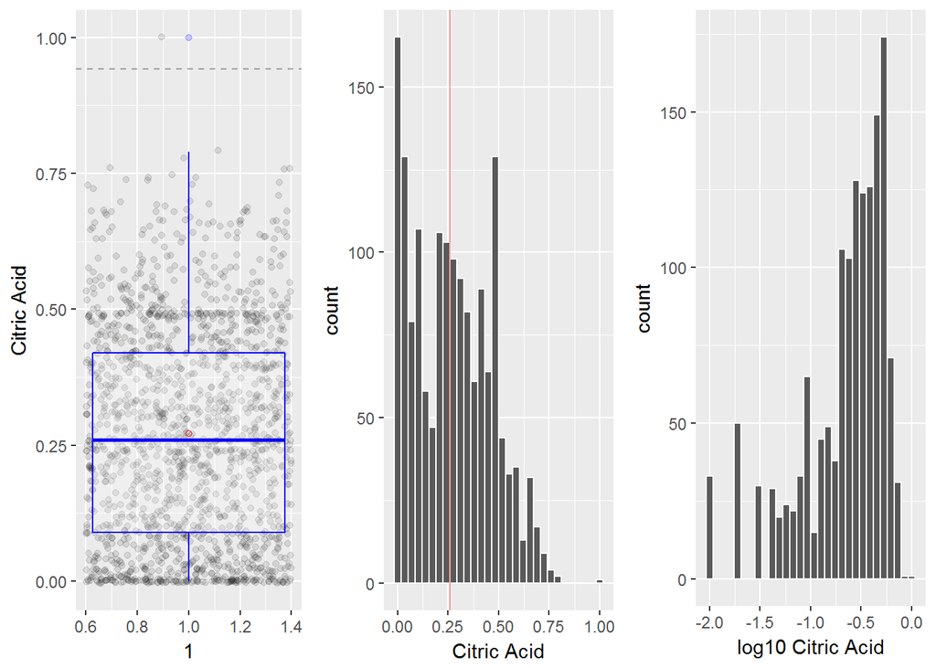

```
##    Min. 1st Qu.  Median    Mean 3rd Qu.    Max.
##   0.000   0.090   0.260   0.271   0.420   1.000
```

- 132 wines have citric acid 0.0
- Citric.acid, did not appear to be normally-distributed with long-tail distribution
- For the log10. Looking at this new distribution it is interesting that the distribution has switched from a long-right-tail to a long-left-tail distribution
- There are alot of 0 which means a lot of wine don’t has citric acid. It make sense because citric acid is added as a freshner or flavor to wines not as a key ingredients in cooking wine. ([and also it is prohibited in the EU](https://en.wikipedia.org/wiki/Acids_in_wine#Citric_acid))

### Residual Sugar

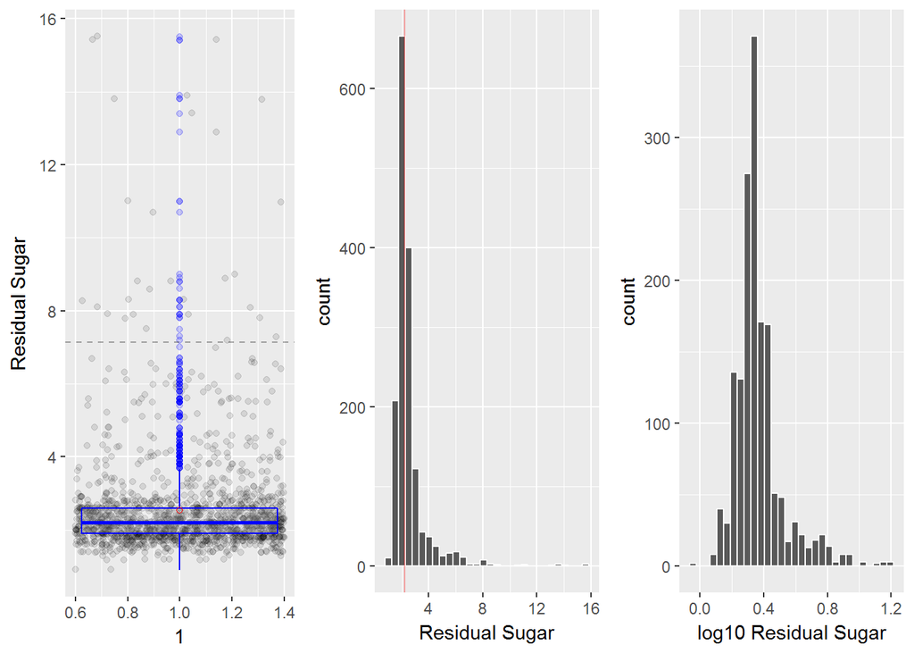

```
##    Min. 1st Qu.  Median    Mean 3rd Qu.    Max.
##   0.900   1.900   2.200   2.539   2.600  15.500
```

- Residual sugar has a very long-tail distribution with many outliers. Some of these outliers are more than 9 standard deviations away from the median! It will be interesting to see how these outliers affect the quality of wine.
- In the log10 plots, the values are still very skewed, but it looks more like a normal distribution.
- High peaks at around 2.3 with many outliers present at the higher ranges.

### Chlorides

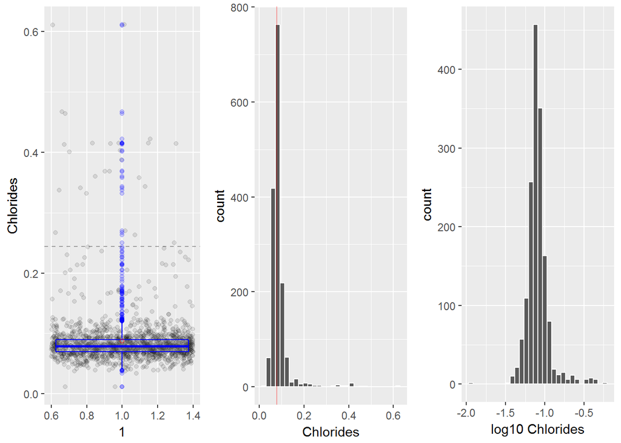

```
##    Min. 1st Qu.  Median    Mean 3rd Qu.    Max.
## 0.01200 0.07000 0.07900 0.08747 0.09000 0.61100
```

- Very similar to residual sugar, chlorides have a strong concentration of points around the median, as well as many outliers.
- The more extreme outliers are as much as 11 standard deviations away from the mean.
- In the log10 plots, we can see that the data still has a long-tail skew, but looks more normally distributed.

### Free Sulphur Dioxide

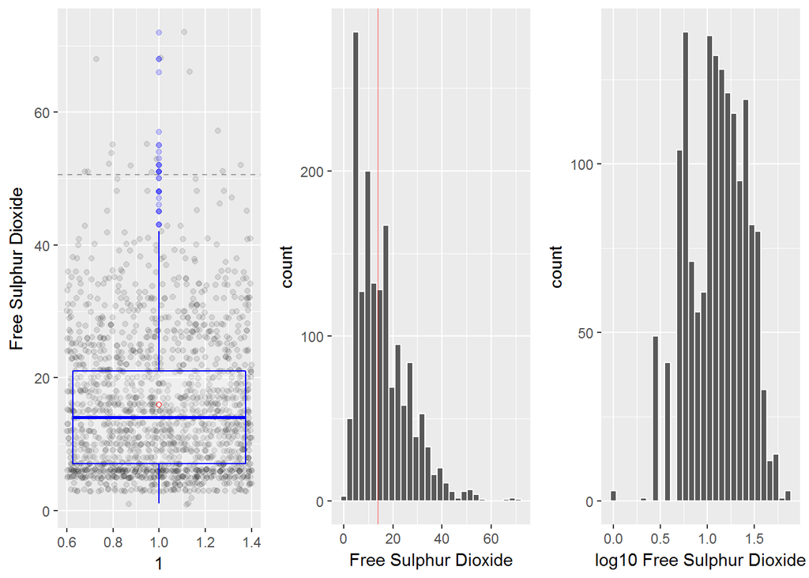

```
##    Min. 1st Qu.  Median    Mean 3rd Qu.    Max.
##    1.00    7.00   14.00   15.87   21.00   72.00
```

- For Free Sulphur Dioxide, there is a high peak at 7 but then it again follows the same positively skewed long tailed patterns
- The median is 14 and 75% of free sulfur concentration is less than 21 but a maximum value is of 72.
- In log10 plot, the distribution appears to be binomial and dispersed

### Total Sulfur Dioxide

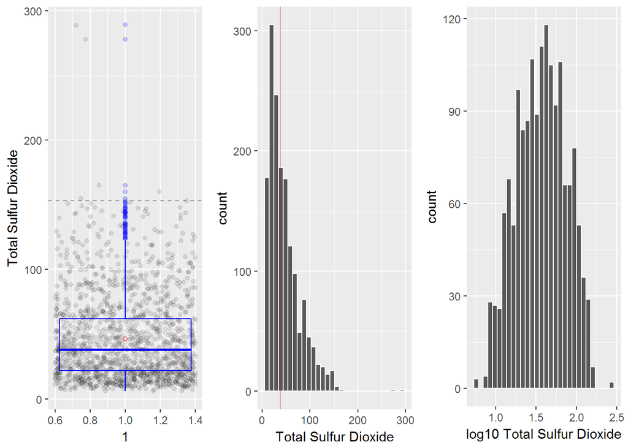

```
##    Min. 1st Qu.  Median    Mean 3rd Qu.    Max.
##    6.00   22.00   38.00   46.47   62.00  289.00
```

- Total sulfur dioxide distribution not that dispersed, as the free sulfur dioxide and its interquartile range does not look quite as large.
- In log10 plot, looks normally distributed.
- The median is 38. 75% of the wines have a concentration below 62.

### Density

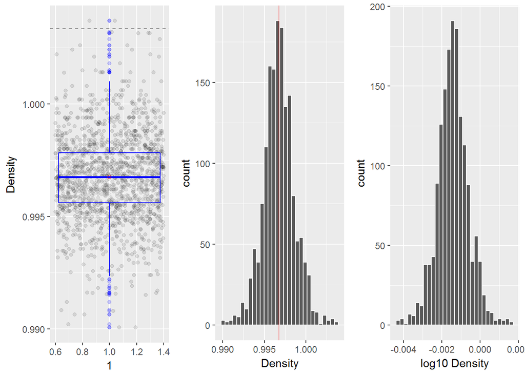

```
##    Min. 1st Qu.  Median    Mean 3rd Qu.    Max.
##  0.9901  0.9956  0.9968  0.9967  0.9978  1.0037
```

- Density varies from 0.99 to 1 only. Its a very little variation. Most of the wines have around 0.997 density value.
- The distribution is normal.

### PH

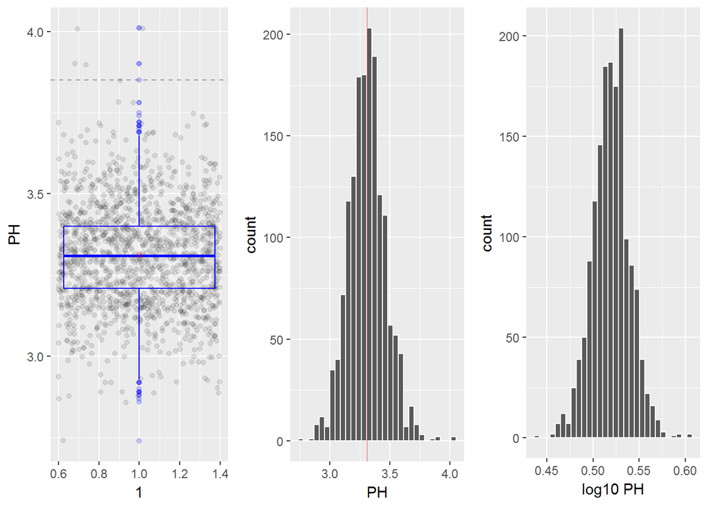

```
##    Min. 1st Qu.  Median    Mean 3rd Qu.    Max.
##   2.740   3.210   3.310   3.311   3.400   4.010
```

- Normal looking distribution, with most of the pH values falling between 3.1 and 3.5 and a median of 3.310

### Sulphates

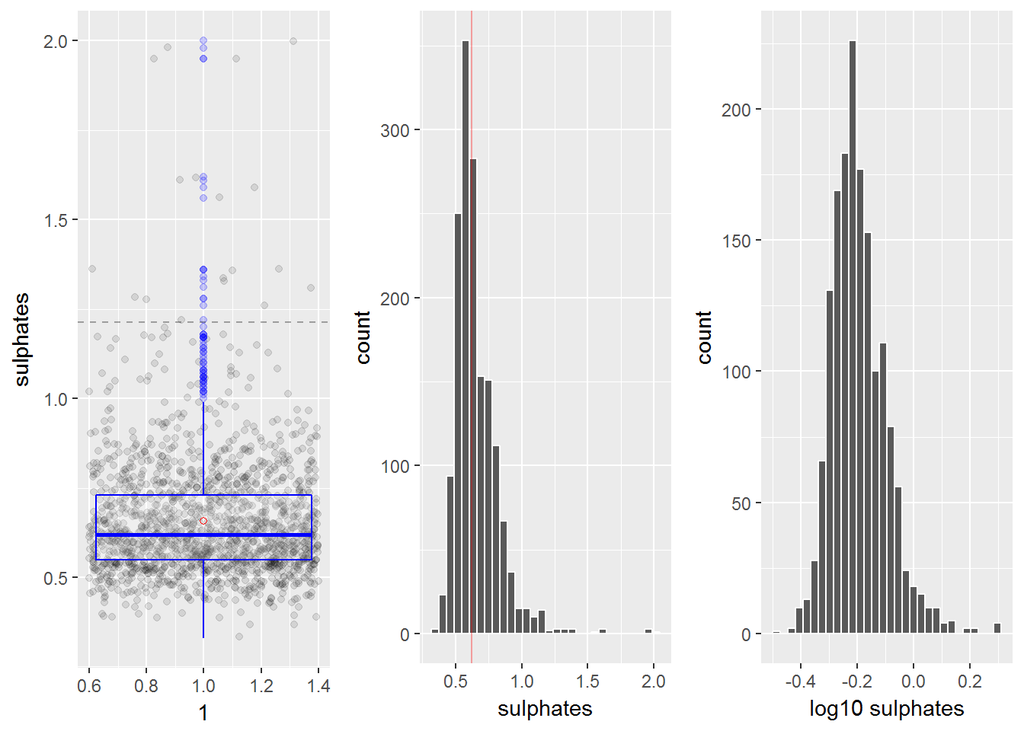

```
##    Min. 1st Qu.  Median    Mean 3rd Qu.    Max.
##  0.3300  0.5500  0.6200  0.6581  0.7300  2.0000
```

- The sulfates distribution is skewed to the right and has many big outliers
- In log10 plot sulphates is much more normally distributed
- Most of the values of sulphate are around 0.6

### Alcohol

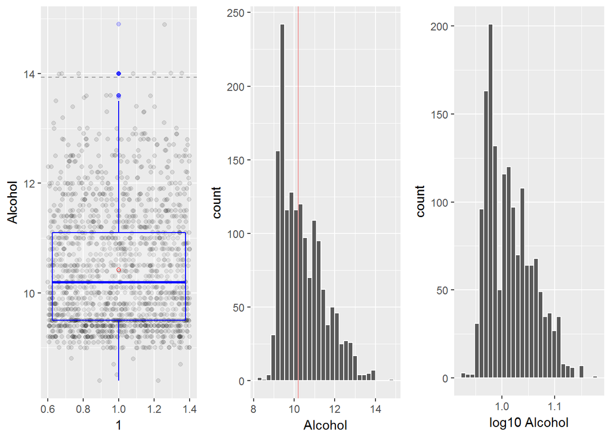

```
##    Min. 1st Qu.  Median    Mean 3rd Qu.    Max.
##    8.40    9.50   10.20   10.42   11.10   14.90
```

- Most wines have less than 11% alcohol.
- The alcohol has distribution skewed to the right, some peaks and a median of 10.2.
- Only few values of alcohol amount lie below 9 and above 13.

# Univariate Analysis

### What is the structure of your dataset?

The Red Wine Dataset had 1599 observations with 13 variables. All the variables are numerical, expect for quality, which is an categorical. The categorical variable indicate the quality of the wine, at least 3 wine experts rated the quality of each wine, and rated it between 0 (bad) and 10 (excellent).

### What is/are the main feature(s) of interest in your dataset?

By univariate analysis, we could notice :

- 82.5% of the wines are rated either a 5 or 6
- Most wines have an alcohol content of less than 11%
- 34% fixed.acidity values between [7,8] and 78% Citric.acid values below 0.5
- pH and density are the most normally distributed features
- Residual sugar, chlorides, sulphates all have big outliers

We want to analyse the quality, so quality is the main feature of interest.

### What other features in the dataset do you think will help support your investigation into your feature(s) of interest?

Unsure how the multiple acidity variables relate to each other and quality. We notice that Citric.acid is the only variable with observations equal to zero. And we think sulphates, chlorides may help to analyse the quality of wine as well.

### Did you create any new variables from existing variables in the dataset?

Yes, we changed quality to an ordered factor and created a new variable called “rating”" to classifying wines as bad, average or good based on quality.

### Of the features you investigated, were there any unusual distributions? Did you perform any operations on the data to tidy, adjust, or change the form of the data? If so, why did you do this?

- Citric acid has a unique distribution as compared to the other numeric variables. It almost has a rectangular shape apart from a few outliers
- More than 80% rathed between 5 and 6, so this less informations will make it hard to go out with a good result
- Tidy adjustments not made to data
- Change the quality type into an ordered feature

# Bivariate Plots Section

In this section we will analyse our red wine dataset with 2 variables at a time. starting with a correlation graph may help us.

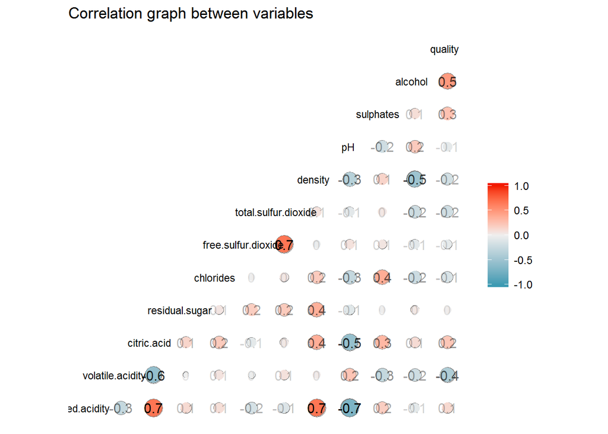

- This plot shows that quality is strongly correlated positively with alcohol and sulfates, and negatively with volatile.acidity
- Residual.sugar on the other hand is not correlated at all with quality
- Density and fixed.acidity are two features with strong positive correlation.
- There is also an expected strong negative correlation between pH and fixed/citric.acid, and another negative correlation between alcohol and density.
- Volatile.acidity has a positive correlation with pH! (We know that when decreasing pH, acidity increases

To get a quick snapshot of how the variables affect quality we will use  
boxplots

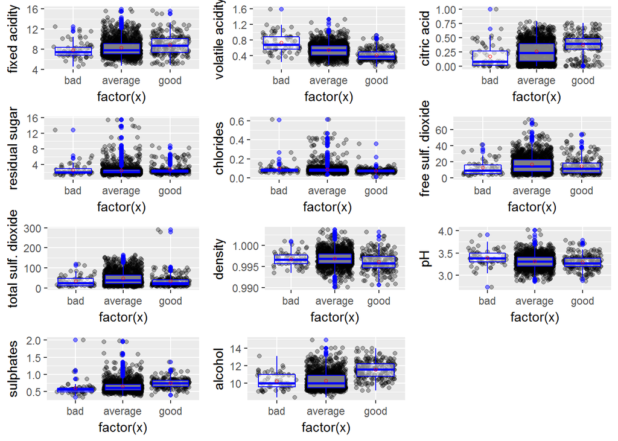

A ‘good’ wine generally has these trends:

- Higher fixed acidity and citric acid, lower volatile acidity
- Lower pH
- Higher sulphates
- Higher alcohol

**Let’s see now the relation between different features**

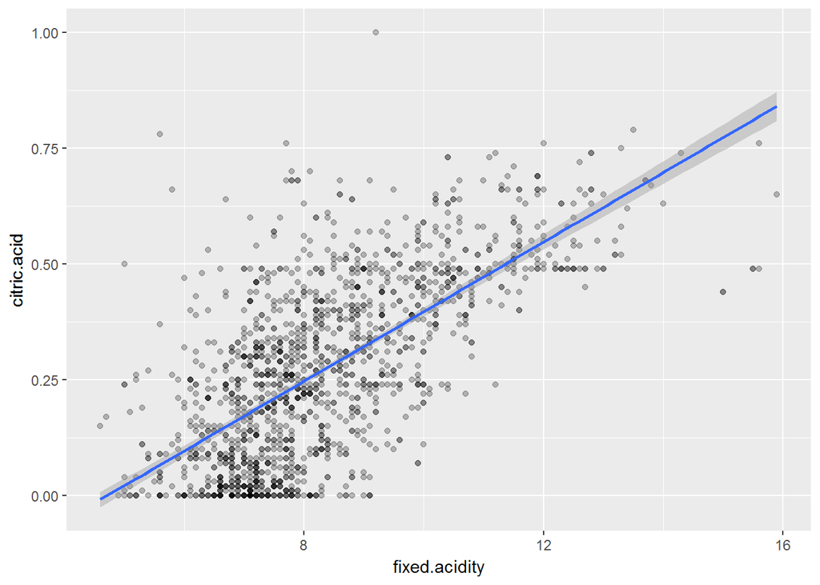

```
##
##  Pearson's product-moment correlation
##
## data:  redwine$fixed.acidity and redwine$citric.acid
## t = 36.234, df = 1597, p-value < 2.2e-16
## alternative hypothesis: true correlation is not equal to 0
## 95 percent confidence interval:
##  0.6438839 0.6977493
## sample estimates:
##       cor
## 0.6717034
```

- Citric acid and fixed acidity have a strong positive correlation of 0.67
- Citric acid has a weak positive correlation of 0.23 with quality while fixed acidity has a very weak positive correlation of 0.12.

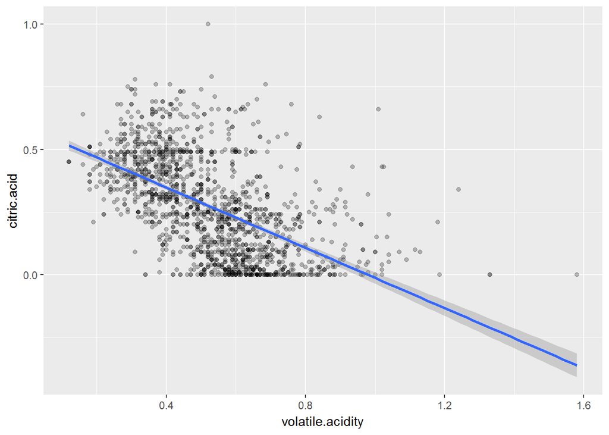

```
##
##  Pearson's product-moment correlation
##
## data:  redwine$volatile.acidity and redwine$citric.acid
## t = -26.489, df = 1597, p-value < 2.2e-16
## alternative hypothesis: true correlation is not equal to 0
## 95 percent confidence interval:
##  -0.5856550 -0.5174902
## sample estimates:
##        cor
## -0.5524957
```

- Citric acid and volatile acidity have a negative correlation of -0.55

# Bivariate Analysis

### Talk about some of the relationships you observed in this part of the investigation. How did the feature(s) of interest vary with other features in the dataset?

Correlation plot helped to understand the correlation among different features. Quality is strongly correlated positively with alcohol and sulfates, and negatively with volatile acidity. Good wines have lower pH values, which also goes with having more fixed and citric acid.

### Did you observe any interesting relationships between the other features (not the main feature(s) of interest)?

- Citric acid and fixed acidity have a strong positive correlation of 0.7, while citrict acid and volatile acidity have a moderate negative correlation of -0.6
- Density and fixed acidity are two features with strong positive correlation of 0.7
- Negative correlation between alcohol and density
- An expected strong negative correlation between pH and fixed and citric acid
- A surprising positive correlation between pH and volatile acidity, since a higher pH value means less acidity, but a higher volatile acidity means more acidity.

### What was the strongest relationship you found?

- Normal correlations between quality and other features

```
##        fixed.acidity     volatile.acidity          citric.acid
##           0.12405165          -0.39055778           0.22637251
##       residual.sugar            chlordies  free.sulfur.dioxide
##           0.01373164          -0.12890656          -0.05065606
## total.sulfur.dioxide              density                   pH
##          -0.18510029          -0.17491923          -0.05773139
##            sulphates              alcohol
##           0.25139708           0.47616632
```

- Correlations log10 between quality and other features

```
##        fixed.acidity     volatile.acidity          citric.acid
##           0.11423756          -0.39124918                  NaN
##       residual.sugar            chlordies  free.sulfur.dioxide
##           0.02353331          -0.17613996          -0.05008749
## total.sulfur.dioxide              density                   pH
##          -0.17014272          -0.17517368          -0.05757386
##            sulphates              alcohol
##           0.30864193           0.47698109
```

We can say that the following variables have relatively higher correlations to wine quality:

- alcohol
- volatile acidity
- sulphates (log10)
- citric acid

Between other features, the strongest relationship appeared to be pH and fixed acidity, which had a nagtive correlation of -0.683.

# Multivariate Plots Section

In this section we are going to create a few multivariate plots to investigate more complex interactions between the variables that are most related to quality of the wine. Then we willcreate some mathematical models.

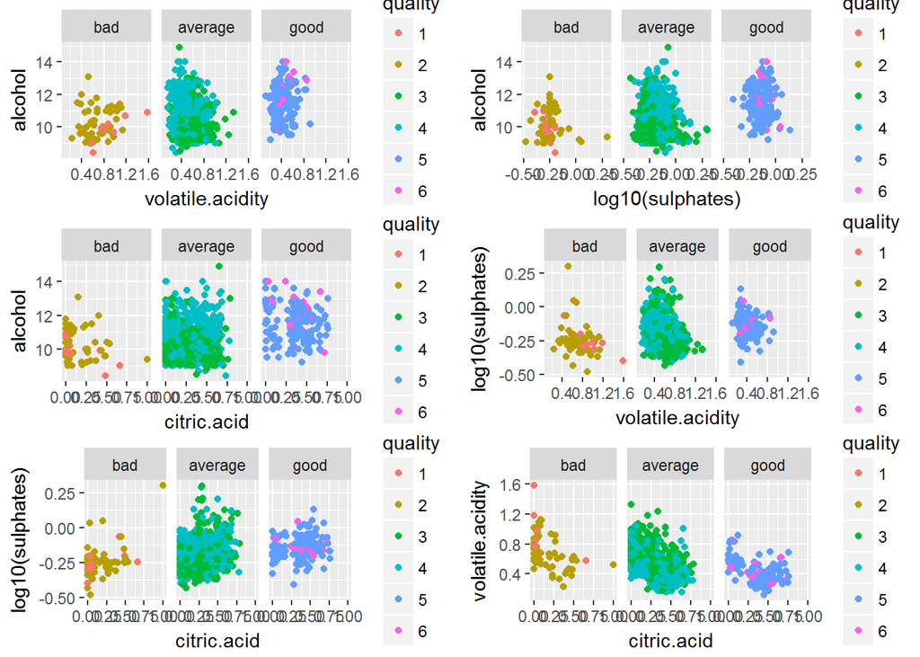

These scatterplots were crowded since more than 80% have average quality, so we faceted by rating. It is now more clear that higher quality wines tend to be higher in alcohol, citric acid and sulphates. On the other hand, higher quality wines tend to be lower in volatile acidity.

### Linear models

```
##
## Calls:
## m1: lm(formula = as.numeric(quality) ~ alcohol, data = subset(redwine,
##     citric.acid == 0))
## m2: lm(formula = as.numeric(quality) ~ alcohol + volatile.acidity,
##     data = subset(redwine, citric.acid == 0))
## m3: lm(formula = as.numeric(quality) ~ alcohol + volatile.acidity +
##     I(log10(sulphates)), data = subset(redwine, citric.acid ==
##     0))
## m4: lm(formula = as.numeric(quality) ~ alcohol + volatile.acidity +
##     I(log10(sulphates)) + citric.acid + chlorides + density +
##     pH, data = subset(redwine, citric.acid == 0))
##
## ==========================================================================
##                            m1           m2           m3           m4
## --------------------------------------------------------------------------
##   (Intercept)             0.549        2.344***     2.968***     2.638
##                          (0.578)      (0.631)      (0.634)     (57.704)
##   alcohol                 0.272***     0.219***     0.193***     0.235*
##                          (0.055)      (0.051)      (0.049)      (0.096)
##   volatile.acidity                    -1.799***    -1.468***    -1.222**
##                                       (0.347)      (0.347)      (0.384)
##   I(log10(sulphates))                               2.550***     2.856**
##                                                    (0.753)      (0.877)
##   chlorides                                                     -2.624
##                                                                 (2.116)
##   density                                                        3.014
##                                                                (57.156)
##   pH                                                            -0.866
##                                                                 (0.519)
## --------------------------------------------------------------------------
##   R-squared               0.160        0.305        0.362        0.382
##   adj. R-squared          0.154        0.294        0.347        0.352
##   sigma                   0.745        0.680        0.654        0.652
##   F                      24.785       28.330       24.246       12.870
##   p                       0.000        0.000        0.000        0.000
##   Log-likelihood       -147.435     -134.921     -129.254     -127.204
##   Deviance               72.153       59.691       54.780       53.104
##   AIC                   300.870      277.842      268.508      270.407
##   BIC                   309.518      289.373      282.922      293.470
##   N                     132          132          132          132
## ==========================================================================
```

```
##
## Call:
## lm(formula = as.numeric(quality) ~ alcohol + volatile.acidity +
##     I(log10(sulphates)), data = subset(redwine, citric.acid ==
##     0))
##
## Residuals:
##      Min       1Q   Median       3Q      Max
## -1.91815 -0.28962  0.02895  0.40127  1.89147
##
## Coefficients:
##                     Estimate Std. Error t value Pr(>|t|)
## (Intercept)          2.96777    0.63435   4.678 7.24e-06 ***
## alcohol              0.19311    0.04947   3.903 0.000153 ***
## volatile.acidity    -1.46794    0.34742  -4.225 4.50e-05 ***
## I(log10(sulphates))  2.55002    0.75273   3.388 0.000937 ***
## ---
## Signif. codes:  0 '***' 0.001 '**' 0.01 '*' 0.05 '.' 0.1 ' ' 1
##
## Residual standard error: 0.6542 on 128 degrees of freedom
## Multiple R-squared:  0.3624, Adjusted R-squared:  0.3474
## F-statistic: 24.25 on 3 and 128 DF,  p-value: 1.724e-12
```

It is difficult to predict the quality of wine, given this dataset. We are able to predict 36.2% of what makes a good wine good. After adding chlorides, density and pH to our model we could only improve the prediction with 2%.

# Multivariate Analysis

### Talk about some of the relationships you observed in this part of the investigation. Were there features that strengthened each other in terms of looking at your feature(s) of interest?

High alcohol contribute to good quality of wine, adding sulphates or citric acid will influence the quality of wine positively, while adding volatile acid influences the quality of wine negatively.

### Were there any interesting or surprising interactions between features?

Correlation plot was showing that citric acid influence the quality of wine but from the plots above, we can observe that citric acid alone doen’t influence the quality that much.

### OPTIONAL: Did you create any models with your dataset? Discuss the strengths and limitations of your model.

We created a linear model starting from alcohol adding volatile.acidity, sulphates, chlorides, density and pH, we could only predict 38.2% of the quality. We are not entirely surprised by this limitations given that the correlation between any variable and quality was not very high, and 80% of the dataset was in average.

# Final Plots and Summary

### Plot One: Quality of wine

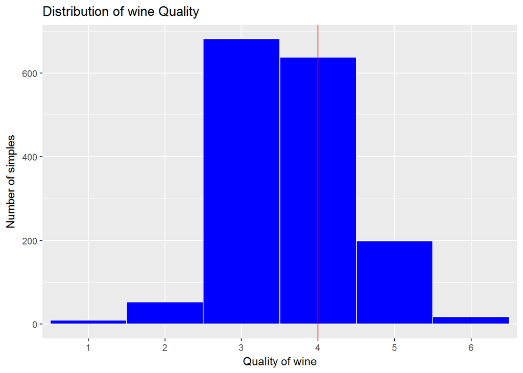

```
##   1   2   3   4   5   6
##  10  53 681 638 199  18
```

This graph explains that 82.5 % of wines in dataset are of quality 5 & 6. As we have to find influence of other metrics on quality of wine such a limited dataset make it difficult to understand what makes good wine.

### Plot Two: Effect of Alcohol

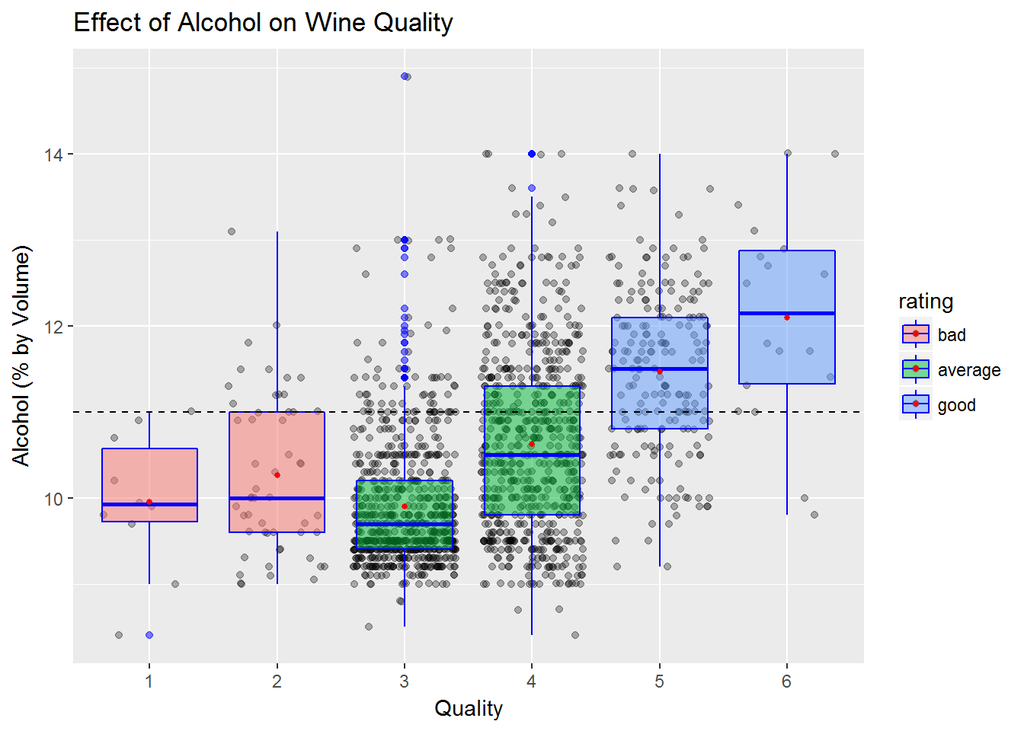

```
##
##  Pearson's product-moment correlation
##
## data:  redwine$alcohol and as.numeric(redwine$quality)
## t = 21.639, df = 1597, p-value < 2.2e-16
## alternative hypothesis: true correlation is not equal to 0
## 95 percent confidence interval:
##  0.4373540 0.5132081
## sample estimates:
##       cor
## 0.4761663
```

```
## redwine$rating: bad
##    Min. 1st Qu.  Median    Mean 3rd Qu.    Max.
##    8.40    9.60   10.00   10.22   11.00   13.10
## --------------------------------------------------------
## redwine$rating: average
##    Min. 1st Qu.  Median    Mean 3rd Qu.    Max.
##    8.40    9.50   10.00   10.25   10.90   14.90
## --------------------------------------------------------
## redwine$rating: good
##    Min. 1st Qu.  Median    Mean 3rd Qu.    Max.
##    9.20   10.80   11.60   11.52   12.20   14.00
```

### Plot Three: Alcohol and volatile acidity

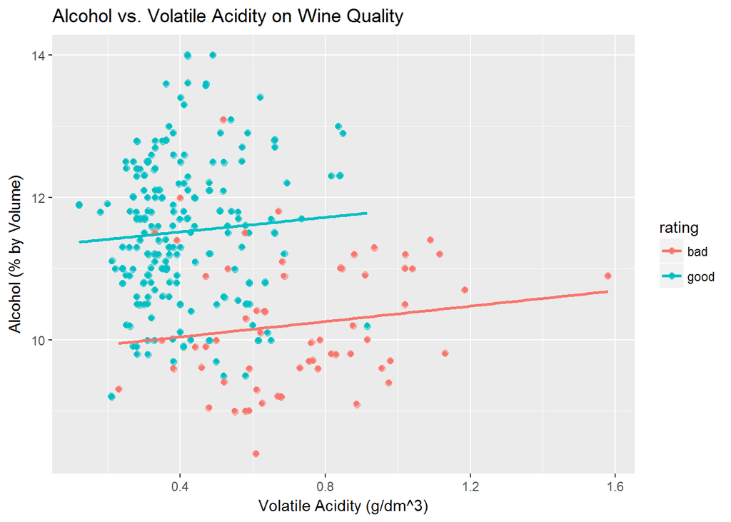

*We subsetted the data to take off the ‘average’ wines.* Hight volatile acidity - with few exceptions - made wine quality down. *We notice that the lines make is more clear to see the relationship alcohol and volatile acidity by rating.* **High quality wine have a combination of high alcohol content and low volatile acidity**

# Reflection

Through this exploratory data analysis of red wine dataset, We can assume how domain knowledge is helpful during the process. We could reveals the key factor affecting the quality of wine, mainly: alcohol, sulphates, and volatile acidity even tough we had a limited data of 1599 observations. In that dataset 82% of the wines are of avergae quality betwen 5 & 6. If we could have a dataset of more observations and an uniform quality of wines. Then we will be able to perform a better analysis.

The linear model which we have used for the prediction is not a good model as its coefficient of determination was very low. For the further study we would try differnt modeling technic; it might give more accuracy.

*Enjoy the code [here](https://github.com/anoru/Red-Wine-Exploratory-Data-Analysis-by-R)*

# Opening to more reseach for the reader

[Receiving Operating Characteristic, or ROC](https://en.wikipedia.org/wiki/Receiver_operating_characteristic), is a visual way for inspecting the performance of a binary classifier (0/1). This is just a test, and our binary classifier for this dataset is if the quality more than 5 (1), or less than 5 (0). We are comparing the rate at which our classifier is making correct predictions (True Positives or TP) and the rate at which your classifier is making false alarms (False Positives or FP). We will use a generalized linear models (Just to change the linear model)

for more informations check this : [ROC Curves in Python and R](http://blog.yhat.com/posts/roc-curves.html)

```
##
## Call:
## glm(formula = as.numeric(quality) ~ alcohol + volatile.acidity +
##     I(log10(sulphates)) + citric.acid + chlorides + density +
##     pH, data = training)
##
## Deviance Residuals:
##      Min        1Q    Median        3Q       Max
## -2.62956  -0.37731  -0.03654   0.46055   1.96488
##
## Coefficients:
##                     Estimate Std. Error t value Pr(>|t|)
## (Intercept)         -1.85907   13.63280  -0.136 0.891553
## alcohol              0.31152    0.02296  13.570  < 2e-16 ***
## volatile.acidity    -1.21469    0.13858  -8.765  < 2e-16 ***
## I(log10(sulphates))  1.78917    0.22313   8.019 2.52e-15 ***
## citric.acid         -0.35674    0.15587  -2.289 0.022267 *
## chlorides           -1.70488    0.44716  -3.813 0.000144 ***
## density              5.46542   13.57073   0.403 0.687214
## pH                  -0.59259    0.15094  -3.926 9.13e-05 ***
## ---
## Signif. codes:  0 '***' 0.001 '**' 0.01 '*' 0.05 '.' 0.1 ' ' 1
##
## (Dispersion parameter for gaussian family taken to be 0.4212071)
##
##     Null deviance: 799.45  on 1209  degrees of freedom
## Residual deviance: 506.29  on 1202  degrees of freedom
## AIC: 2397.6
##
## Number of Fisher Scoring iterations: 2
```

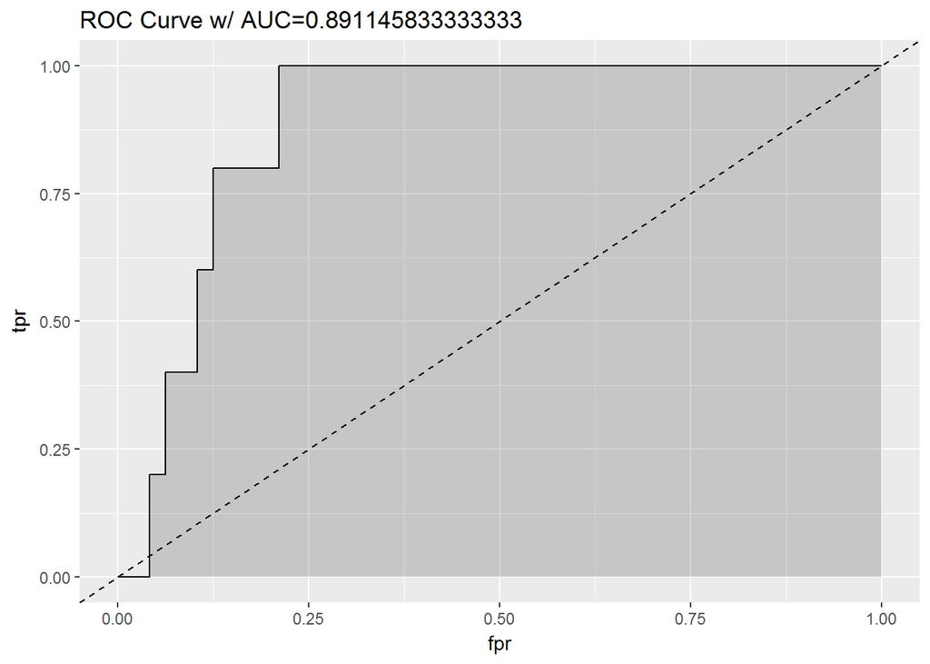